# Suicide and Economic Crisis: The Evolution of the Phenomenon in Italy

Nadia Napolano

2025-08-14

A country’s economic conditions and socio-economic stability profoundly influence collective well-being. Their effects, however, extend beyond material security to shape emotional development and individual well-being. Throughout life, different socio-economic contexts could lead to markedly different versions of ourselves — more stable or more fragile. Considering this perspective, this thesis examines the relationship between socio-economic conditions and suicide rates in Italy between 2005 and 2020, with particular attention to the damaging role of the 2008 global financial crisis. The objective of the analysis is to understand how economic instability and regional disparities interact with individual vulnerability, showing that suicide cannot be interpreted only as a personal event but must also be interpreted as a social outcome shaped by broader structural dynamics.

These are all the libraries that are going to be used for the analysis.

```r
library(readxl)
library(ggplot2)
library(dplyr)
library(corrplot)
library(RColorBrewer)
library(mapSpain)
library(sf)
library(cowplot)
library(tidyverse)
library(plm)
library(car)
library(ggplot2)
library(lmtest)
library(pcse)
library(tseries)
library(sandwich)
library(ggrepel)
library(stringr)
library(ggthemes)
library(rnaturalearth)
```

##Data reading Let’s start adding the data. Four datasets are needed; “data”, “employment_data”, “data_graph” and “suicide_data”. They are all in excel and can be found in my github public page.

```r
library(readxl)
data <- read_excel("C:/Users/utente/Desktop/Nadia Napolano task 1,,_files/data.xlsx")
data_graph <- read_excel("C:/Users/utente/Desktop/Nadia Napolano task 1,,_files/data_graph.xlsx")
employment_data <- read_excel("C:/Users/utente/Desktop/Nadia Napolano task 1,,_files/employment_data.xlsx")
dati_suicidio_it <- read_excel("C:/Users/utente/Desktop/Nadia Napolano task 1,,_files/dati suicidio it.xlsx")
```

#Suicide data table

A first look at the main statistical insights about the dependent variable: “suicide index”.

```r
df_statistiche_region<- data |>
  group_by(region) |>
  summarise(
    average = mean(suicide_index, na.rm = TRUE),
    minimum = min(suicide_index, na.rm = TRUE),
    maximum = max(suicide_index, na.rm = TRUE),
    variance = var(suicide_index, na.rm = TRUE),
    .groups = "drop"
  )
df_statistiche_year <- data |>
  group_by(TIME_PERIOD) |>
  summarise(
    average = mean(suicide_index, na.rm = TRUE),
    minimum = min(suicide_index, na.rm = TRUE),
    maximum = max(suicide_index, na.rm = TRUE),
    variance = var(suicide_index, na.rm = TRUE),
    .groups = "drop"
  )
```

## Graphs

In the first part, some graphs will be designed to improve the understanding of the data available.

#Employment data

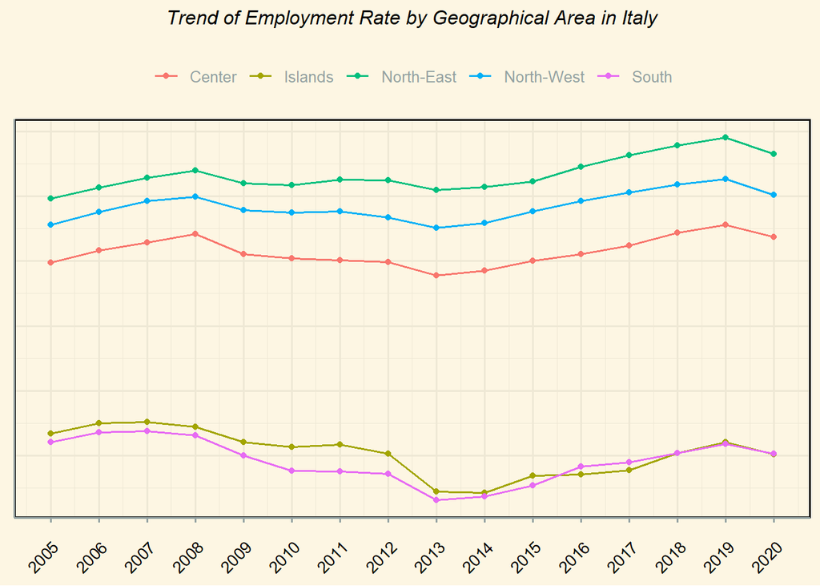

```r
ggplot(data_graph, aes(x = TIME_PERIOD, y = employment, color = geo_area)) +
  geom_line(size = 0.7) +
  geom_point(size = 1.5) +
  scale_x_continuous(
  breaks = seq(min(data_graph$TIME_PERIOD), max(data_graph$TIME_PERIOD), by = 1)
  ) +
  labs(
    title = "Trend of Employment Rate by Geographical Area in Italy"
  ) +
  theme_solarized(light = TRUE) +
  theme(
    plot.title = element_text(size = 12, face = "italic", hjust = 0.5, color = "black", margin = margin(b = 15)),
    axis.title = element_blank(),
    axis.text = element_text(size = 10, color = "black"),
    axis.text.x = element_text(angle = 45, hjust = 1, margin = margin(t = 10)),
    axis.text.y = element_blank(),
    axis.ticks.y = element_blank(),
    panel.border = element_rect(color = "black", fill = NA, linewidth = 1),
    legend.title = element_blank(),
    legend.position = "top"
  )
```

The graph highlights economic inequalities in Italy through employment trends, showing that the South and the Islands face a significant gap compared to the rest of the country.

# Suicides behaviour in the Country

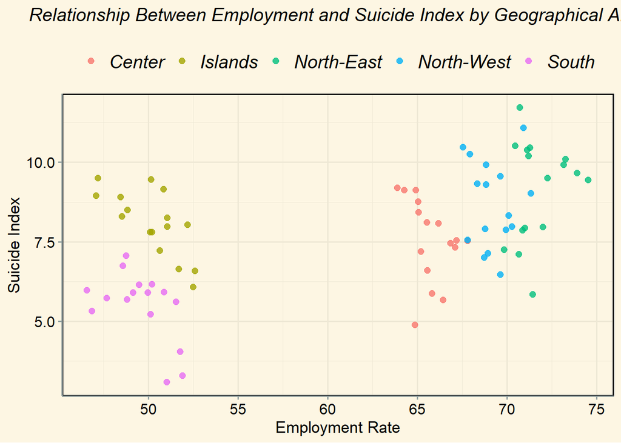

```r
# Scatterplot
p<-ggplot(data_graph, aes(x = employment, y = suicidi_index, color = geo_area)) +
  geom_point(size = 2.2, alpha = 0.8) +
  labs(
    title = "Relationship Between Employment and Suicide Index by Geographical Area",
    x = "Employment Rate",
    y = "Suicide Index"
  ) +
  theme_solarized(light = TRUE) +
 theme(
  plot.title = element_text(size = 15, face = "italic", hjust = 0.5, color = "black", margin = margin(b = 15)),
  axis.text = element_text(size = 12, color = "black"),
  axis.title = element_text(size = 13, color = "black"),
  panel.border = element_rect(color = "black", fill = NA, linewidth = 1),
  legend.title = element_blank(),
  legend.position = "top",
  legend.text = element_text(size = 15, color = "black", face= "italic")
)
p
```

# Employment graph

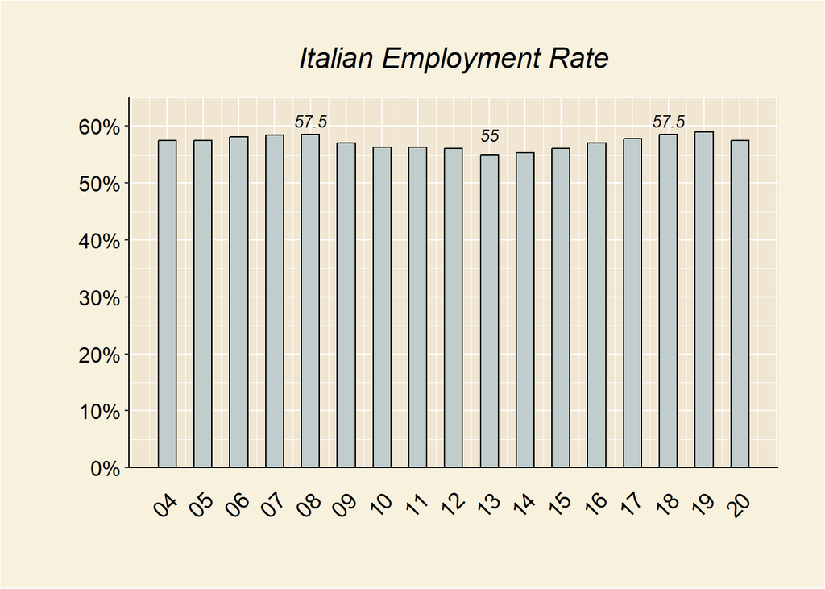

```r
#labeling data
label_data <- data.frame(
  Year = c(2013, 2008, 2018),
  value = c(55, 57.5, 57.5),
  label = c("55", "57.5", "57.5")
)

max_label_value <- 65
#graph design
p<-employment_data |>
  ggplot(aes(x = Year, y = occupation_15_65_it)) +
  geom_col(width = 0.5, fill = "azure3", color = "black") +
  geom_text(data = label_data, aes(x = Year, y = value + 3.5, label = label),
            color = "black", size = 3.5, fontface = "italic") +
  scale_x_continuous(
    breaks = unique(employment_data$Year),
    labels = function(x) substr(as.character(x), 3, 4)
  ) +
  scale_y_continuous(
    limits = c(0, max_label_value),
    breaks = scales::pretty_breaks(n = 5),
    labels = function(x) paste0(x, "%"),
    expand = expansion(0)
  ) +
  labs(
    x = "",
    y = "",
    title = "Italian Employment Rate"
  ) +
  theme(
    plot.margin = unit(c(1, 1, 1, 1), "cm"),
    panel.background = element_rect(fill = "#f0e6d2"),
    plot.background = element_rect(fill = "#f7f1de"),
    plot.title = element_text(size = 17.5, face = "italic",
                              hjust = 0.5,
                              margin = margin(b = 15)),
    axis.line = element_line(color = "black"),
    axis.title = element_text(size = 10, color = "black",
                              face = "bold"),
    axis.text = element_text(size = 8, color = "black"),
    axis.text.x = element_text(angle = 45, hjust = 1, margin = margin(t = 10), size = 13.7),
    axis.text.y = element_text(size = 13),
    axis.title.y = element_text(margin = margin(r = 10)),
    axis.ticks.x = element_blank()
  )
p
```

The graph shows employment trends in Italy: the values reflect the 2008 crisis, with a negative trend until 2013, when they start to rise again. In 2020, a new decline in employment is observed due to the COVID-19 pandemic.

# Suicide in italy between 2005-2020

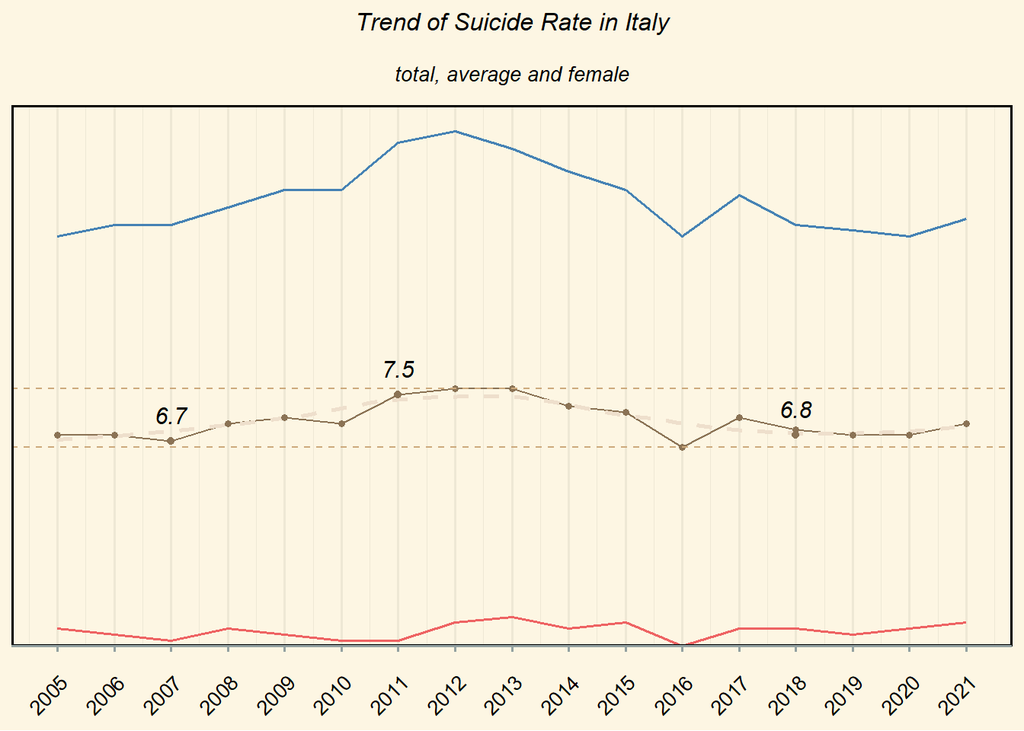

```r
min_suicide <- min(dati_suicidio_it$Suicides_100000, na.rm = TRUE)
max_suicide <- max(dati_suicidio_it$Suicides_100000, na.rm = TRUE)

#Let's highlight some values
valori_evidenziati <- data.frame(
  year = c(2007, 2011, 2018),
  Suicides_100000 = c(6.7, 7.5, 6.8)
)

grafico <- dati_suicidio_it |>
  ggplot(aes(x = year)) +
  geom_line(aes(y = Suicides_100000), size = 0.5, color = "burlywood4") +
  stat_smooth(aes(y = Suicides_100000), se = FALSE, linetype = "dashed", color = "antiquewhite2", alpha = 0.4) +
  geom_point(aes(y = Suicides_100000), size = 1.2, color = "burlywood4") +
  geom_point(data = valori_evidenziati, aes(y = Suicides_100000), color = "burlywood4", size = 1.5) +
  geom_text(data = valori_evidenziati, aes(y = Suicides_100000, label = Suicides_100000),
            color = "black", vjust = -1, size = 4, fontface = "italic") +
  geom_line(aes(y = female), color = "indianred2", size = 0.6, linetype = "solid") +
  geom_line(aes(y = male), color = "steelblue", size = 0.6, linetype = "solid") +
  geom_hline(yintercept = min_suicide, linetype = "dashed", color = "burlywood3", linewidth = 0.5) +
  geom_hline(yintercept = max_suicide, linetype = "dashed", color = "burlywood3", linewidth = 0.5) +
  scale_y_continuous(
    expand = expansion(mult = c(0, 0.05)),
    breaks = NULL
  ) +
  scale_x_continuous(
    breaks = seq(min(dati_suicidio_it$year), max(dati_suicidio_it$year), by = 1)
  ) +
  labs(
    title = "Trend of Suicide Rate in Italy",
    subtitle = "total, average and female"
  ) +
  theme_solarized(light = TRUE) +
  theme(
    plot.title = element_text(size = 12, face = "italic", hjust = 0.5, color = "black", margin = margin(b = 15)),
    plot.subtitle = element_text(size = 10, face = "italic", hjust = 0.5, color = "black", margin = margin(b = 10)),
    axis.title = element_blank(),
    axis.text = element_text(size = 10, color = "black"),
    axis.text.x = element_text(angle = 45, hjust = 1, margin = margin(t = 10)),
    axis.text.y = element_blank(),      # nasconde numeri y
    axis.ticks.y = element_blank(),     # nasconde tick y
    panel.border = element_rect(color = "black", fill = NA, linewidth = 1)
  )

print(grafico)
```

Data from the International statistic institute of Italy show that suicide rates among men increased during the 2008 recession, with unusually high levels persisting until 2015. For women, the impact was much smaller, with only a slight increase observed between 2012 and 2014.

# Preparing data for designing maps

```r
# average info
mapa_avg <- data |>
  group_by(region) |>
  summarise(suicide_index_mean = mean(suicide_index, na.rm = TRUE)) |>
  ungroup()
# Rename to match `region`
mapping <- c(
  "Piemonte"= "Piemonte",
  "Abruzzo" = "Abruzzo",
  "Basilicata" = "Basilicata",
  "Calabria" = "Calabria",
  "Campania" = "Campania",
  "Emilia Romagna" = "Emilia-Romagna",  # Rename to match `region`
  "Friuli Venezia Giulia" = "Friuli-Venezia Giulia",  # Rename to match `region`
  "Lazio" = "Lazio",
  "Liguria" = "Liguria",
  "Lombardia" = "Lombardia",
  "Marche" = "Marche",
  "Molise" = "Molise",
  "Provincia Autonoma Bolzano" = "Trentino-Alto Adige",  # Merge with Trentino-Alto Adige
  "Provincia Autonoma Trento" = "Trentino-Alto Adige",  # Merge with Trentino-Alto Adige
  "Puglia" = "Apulia",  # Rename to match `region`
  "Sardegna" = "Sardegna",
  "Sicilia" = "Sicily",
  "Toscana" = "Toscana",
  "Umbria" = "Umbria",
  "Valle d'Aosta" = "Valle d'Aosta",
  "Veneto" = "Veneto"

)

# Step 3: Apply the mapping to `data_italy$CCAA`
mapa_avg$region <- mapping[mapa_avg$region]
```

#Map of Italy

The graph shows the average suicide index between 2005 and 2020, providing a quick and clear view of regional patterns in the phenomenon.

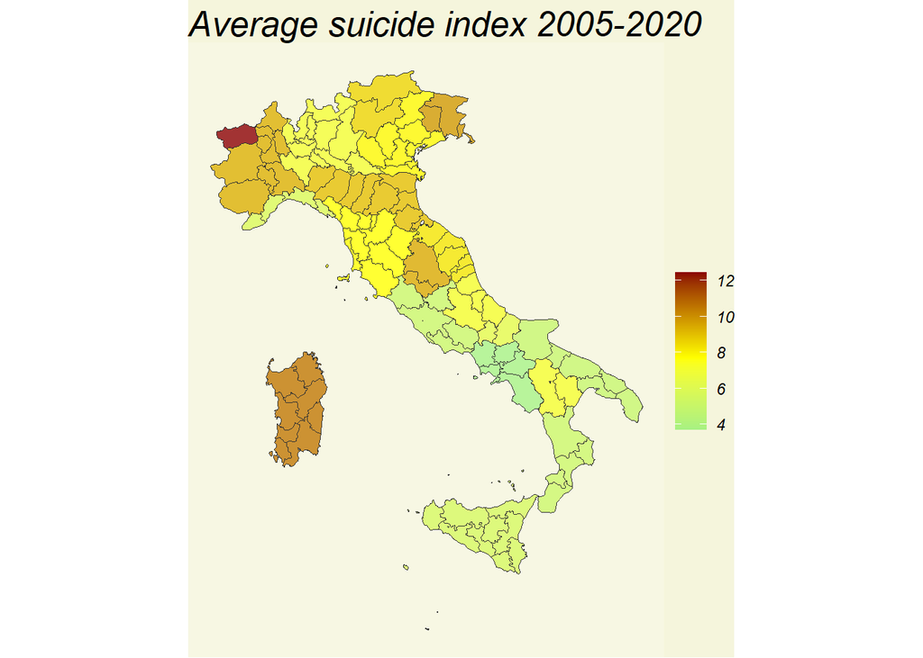

```r
italy <- ne_states(country = "Italy", returnclass = "sf")
mapa_avg_sf <- ne_states(country = "Italy", returnclass = "sf")

mapa_avg_sf <- italy |>
  left_join(mapa_avg, by = c("region" = "region"))
# Creating the map
p1 <- ggplot() +
  geom_sf(data = mapa_avg_sf, aes(fill = suicide_index_mean), color = "black", size = 0.3) +
  annotate("rect", xmin = -Inf, xmax = Inf, ymin = -Inf, ymax = Inf,
           alpha = 0.2, fill = "white") +
  theme_void() +
  labs(
    title = "Average suicide index 2005-2020",
    fill = NULL
  ) +
  theme(
    legend.position = "right",
    plot.title = element_text(face = "italic", size = 19),
    text = element_text(face = "italic"),
 plot.background = element_rect(fill = "#F5F5DC", color = NA),   # beige chiaro
    panel.background = element_rect(fill = "#F5F5DC", color = NA)   # beige chiaro
  ) +
  coord_sf() +
  scale_fill_gradient2(
    low = "lightgreen", mid = "yellow", high = "darkred",
    midpoint = median(mapa_avg_sf$suicide_index_mean, na.rm = TRUE)
  )

#printing the map
print(p1)
```

A clear trend can be observed: suicide is a phenomenon with a significantly higher frequency in northern Italy.

#Gdp italian graph A graph similar to the previous one, but allowing us to observe an economic indicator: GDP per capita.

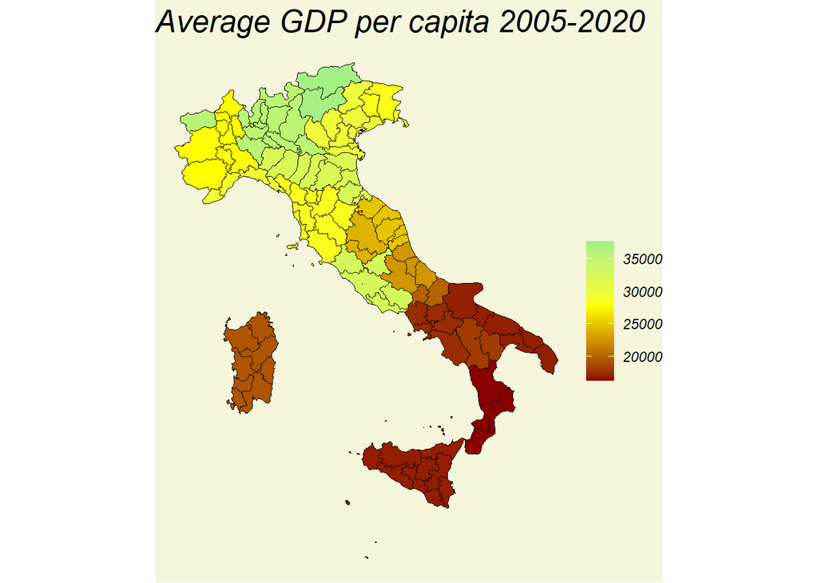

```r
mapa_gdp_sf <- ne_states(country = "Italy", returnclass = "sf")

#getting the data
mapa_gdp_avg <- data |>
  mutate(region = mapping[region]) |>
  group_by(region) |>
  summarise(gdp_percapita_mean = mean(gdp_percapita, na.rm = TRUE)) |>
  ungroup()

mapa_gdp_sf <- italy |>
  left_join(mapa_gdp_avg, by = c("region" = "region"))

# Creating the map
p2 <- ggplot() +
  geom_sf(data = mapa_gdp_sf, aes(fill = gdp_percapita_mean), color = "black", size = 0.3) +
  theme_void() +
  labs(title = "Average GDP per capita 2005-2020", fill = NULL) +
  theme(
    legend.position = "right",
    plot.title = element_text(face = "italic", size = 19),
    text = element_text(face = "italic"),
    plot.background = element_rect(fill = "#F5F5DC", color = NA),
    panel.background = element_rect(fill = "#F5F5DC", color = NA)
  ) +
  coord_sf() +
  scale_fill_gradient2(
    low = "darkred", mid = "yellow", high = "lightgreen",
    midpoint = median(mapa_gdp_sf$gdp_percapita_mean, na.rm = TRUE)
  )

print(p2)
```

The graph shows a clear contrast: GDP per capita in southern Italy is significantly lower, displaying a trend that is almost the mirror image of the previous one.

## Analysis

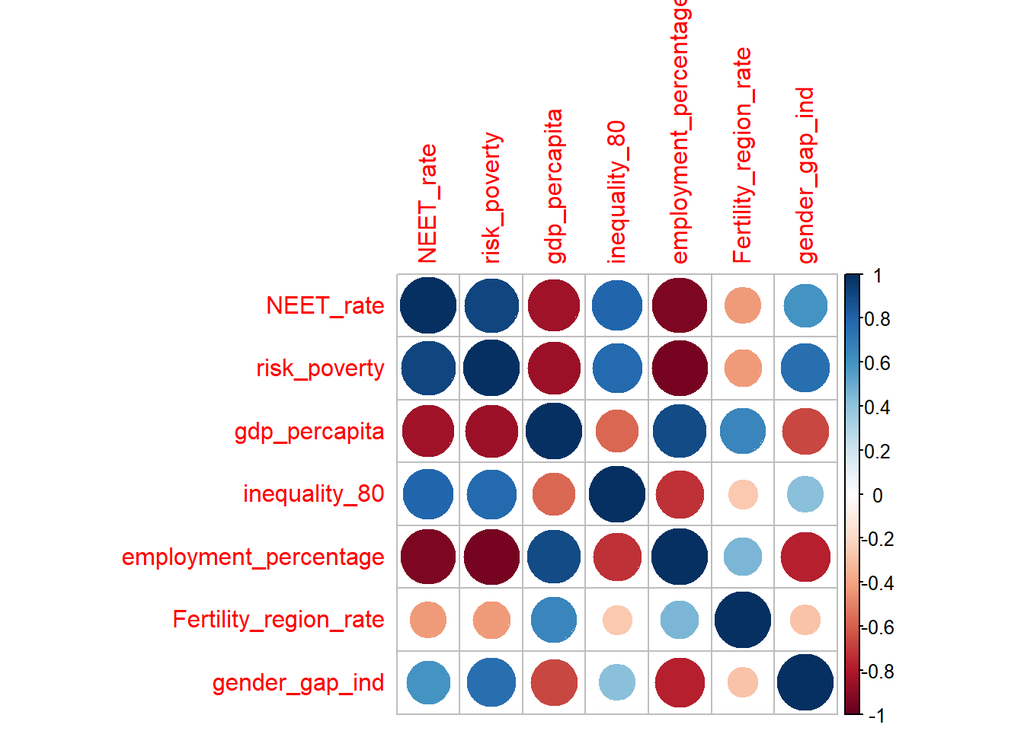

```r
corr_matrix <- cor(data[, c(
  "NEET_rate",
  "risk_poverty",
  "gdp_percapita",
  "inequality_80",
  "employment_percentage",
  "Fertility_region_rate",
  "gender_gap_ind"
)], use = "complete.obs")

corrplot(corr_matrix, method = "circle")
```

Correlations exceeding 0.80 may adversely affect the analysis due to potential multicollinearity issues. Therefore, a Variance Inflation Factor (VIF) test will be conducted subsequently to assess multicollinearity.

## VIF evaluation

```r
library(car)

# Modello OLS con le stesse variabili usate nel panel
ols_model <- lm(suicide_index ~  inequality_80+  geo_area + employment_percentage +population_dummy+ gender_gap_ind+ gdp_percapita+ NEET_rate , data = data)

vif(ols_model)
```

```
##                            GVIF Df GVIF^(1/(2*Df))
## inequality_80          3.465531  1        1.861594
## geo_area              12.612158  4        1.372773
## employment_percentage 31.824255  1        5.641299
## population_dummy       1.638536  1        1.280053
## gender_gap_ind         4.860431  1        2.204638
## gdp_percapita          6.633290  1        2.575517
## NEET_rate             16.057436  1        4.007173
```

The Variance Inflation Factor (VIF) measures how much the variance of a regression coefficient is increased due to multicollinearity. A value higher than 6 is considered to express severe multicollinearity. In this case a selection of variable is needed, considering the correlation observed and the behaviour in the analysis.

##ols analysis

OLS (Ordinary Least Squares) estimates the coefficients of a linear regression by minimizing the sum of the squares of the residuals. It is not ideal for panel data because it ignores unobserved heterogeneity between individuals, risking biased estimates; however, it can be used as a first approach to observe the relationship between variables, before moving on to fixed or random effects models.

```r
ols<-lm(suicide_index ~  inequality_80+  geo_area + employment_percentage +population_dummy+ gender_gap_ind+ gdp_percapita+ NEET_rate, data=data)
summary(ols)
```

```
##
## Call:
## lm(formula = suicide_index ~ inequality_80 + geo_area + employment_percentage +
##     population_dummy + gender_gap_ind + gdp_percapita + NEET_rate,
##     data = data)
##
## Residuals:
##     Min      1Q  Median      3Q     Max
## -6.5991 -0.9442 -0.0479  0.9923  9.1346
##
## Coefficients:
##                         Estimate Std. Error t value Pr(>|t|)
## (Intercept)            7.570e-01  4.640e+00   0.163 0.870510
## inequality_80         -6.579e-01  1.514e-01  -4.345 1.86e-05 ***
## geo_areaIsole          3.337e+00  5.617e-01   5.941 7.28e-09 ***
## geo_areaNord est       7.379e-01  3.525e-01   2.093 0.037080 *
## geo_areaNord ovest     3.432e-01  3.536e-01   0.971 0.332501
## geo_areaSud            1.329e+00  5.343e-01   2.487 0.013392 *
## employment_percentage  2.065e-01  5.404e-02   3.821 0.000159 ***
## population_dummy>4M   -8.975e-01  2.583e-01  -3.475 0.000580 ***
## gender_gap_ind        -2.496e-01  3.414e-02  -7.310 2.08e-12 ***
## gdp_percapita         -6.439e-05  3.332e-05  -1.933 0.054149 .
## NEET_rate              1.842e-01  4.731e-02   3.893 0.000120 ***
## ---
## Signif. codes:  0 '***' 0.001 '**' 0.01 '*' 0.05 '.' 0.1 ' ' 1
##
## Residual standard error: 1.743 on 325 degrees of freedom
## Multiple R-squared:  0.6094, Adjusted R-squared:  0.5974
## F-statistic: 50.71 on 10 and 325 DF,  p-value: < 2.2e-16
```

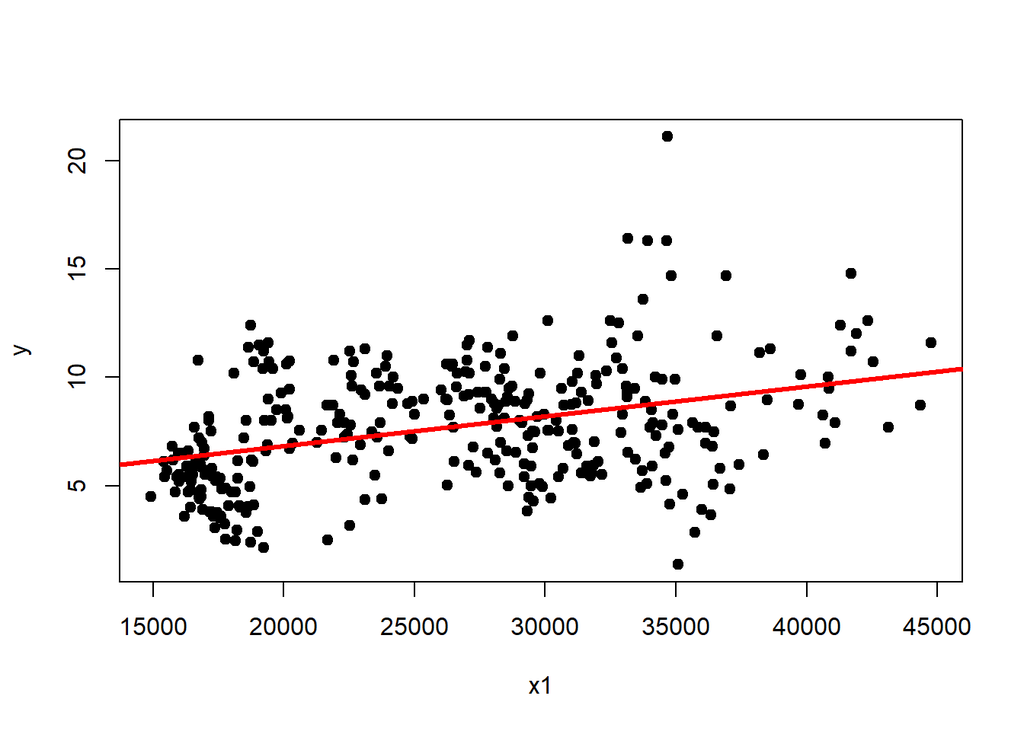

```r
yhat <- ols$fitted
plot(data$gdp_percapita, data$suicide_index, pch=19, xlab="x1", ylab="y")
 abline(lm(data$suicide_index~data$gdp_percapita),lwd=3, col="red")
```

##Ols analysis with the regional variable as factor

```r
 fixed.dum <-lm(suicide_index ~  inequality_80+ gdp_percapita +population_dummy+factor(region)-1, data=data)
summary(fixed.dum)
```

```
##
## Call:
## lm(formula = suicide_index ~ inequality_80 + gdp_percapita +
##     population_dummy + factor(region) - 1, data = data)
##
## Residuals:
##     Min      1Q  Median      3Q     Max
## -6.3661 -0.8558  0.0831  0.8486  8.1257
##
## Coefficients: (1 not defined because of singularities)
##                                            Estimate Std. Error t value Pr(>|t|)
## inequality_80                             2.325e-01  1.422e-01   1.635 0.103026
## gdp_percapita                            -4.903e-04  7.482e-05  -6.554 2.31e-10
## population_dummy<=4M                      1.713e+01  2.042e+00   8.390 1.70e-15
## population_dummy>4M                       2.161e+01  2.505e+00   8.627 3.22e-16
## factor(region)Basilicata                 -2.314e+00  6.586e-01  -3.514 0.000507
## factor(region)Calabria                   -5.424e+00  7.377e-01  -7.352 1.72e-12
## factor(region)Campania                   -1.098e+01  1.078e+00 -10.189  < 2e-16
## factor(region)Emilia Romagna              2.219e+00  6.138e-01   3.615 0.000350
## factor(region)Friuli Venezia Giulia       5.627e+00  7.081e-01   7.947 3.50e-14
## factor(region)Lazio                      -1.730e+00  6.914e-01  -2.502 0.012856
## factor(region)Liguria                     1.988e+00  7.737e-01   2.569 0.010661
## factor(region)Lombardia                   1.771e+00  7.437e-01   2.382 0.017821
## factor(region)Marche                      2.317e+00  6.018e-01   3.850 0.000143
## factor(region)Molise                     -2.276e+00  6.082e-01  -3.743 0.000216
## factor(region)Piemonte                    2.709e-01  5.988e-01   0.452 0.651274
## factor(region)Provincia Autonoma Bolzano  1.251e+01  1.523e+00   8.215 5.65e-15
## factor(region)Provincia Autonoma Trento   6.988e+00  9.921e-01   7.044 1.19e-11
## factor(region)Puglia                     -5.029e+00  7.021e-01  -7.163 5.68e-12
## factor(region)Sardegna                    1.531e+00  6.261e-01   2.445 0.015024
## factor(region)Sicilia                    -9.436e+00  1.117e+00  -8.446 1.15e-15
## factor(region)Toscana                     3.543e+00  7.203e-01   4.918 1.41e-06
## factor(region)Umbria                      3.078e+00  5.865e-01   5.247 2.86e-07
## factor(region)Valle d'Aosta               1.185e+01  1.118e+00  10.593  < 2e-16
## factor(region)Veneto                             NA         NA      NA       NA
##
## inequality_80
## gdp_percapita                            ***
## population_dummy<=4M                     ***
## population_dummy>4M                      ***
```

[output cut: 11 more lines]

```
## factor(region)Provincia Autonoma Bolzano ***
## factor(region)Provincia Autonoma Trento  ***
## factor(region)Puglia                     ***
## factor(region)Sardegna                   *
## factor(region)Sicilia                    ***
## factor(region)Toscana                    ***
## factor(region)Umbria                     ***
## factor(region)Valle d'Aosta              ***
## factor(region)Veneto
## ---
## Signif. codes:  0 '***' 0.001 '**' 0.01 '*' 0.05 '.' 0.1 ' ' 1
##
## Residual standard error: 1.633 on 313 degrees of freedom
## Multiple R-squared:  0.9628, Adjusted R-squared:  0.9601
## F-statistic: 352.6 on 23 and 313 DF,  p-value: < 2.2e-16
```

## Fixed effects model

```r
fe<-plm(suicide_index ~  inequality_80+ gdp_percapita+ NEET_rate, data=data, index=c("region","TIME_PERIOD"), model = "within")
summary(fe)
```

```
## Oneway (individual) effect Within Model
##
## Call:
## plm(formula = suicide_index ~ inequality_80 + gdp_percapita +
##     NEET_rate, data = data, model = "within", index = c("region",
##     "TIME_PERIOD"))
##
## Balanced Panel: n = 21, T = 16, N = 336
##
## Residuals:
##      Min.   1st Qu.    Median   3rd Qu.      Max.
## -6.074096 -0.831038 -0.044849  0.779307  8.275548
##
## Coefficients:
##                  Estimate  Std. Error t-value  Pr(>|t|)
## inequality_80 -5.3371e-02  1.4074e-01 -0.3792    0.7048
## gdp_percapita -6.0124e-05  9.6597e-05 -0.6224    0.5341
## NEET_rate      2.8775e-01  4.4287e-02  6.4975 3.227e-10 ***
## ---
## Signif. codes:  0 '***' 0.001 '**' 0.01 '*' 0.05 '.' 0.1 ' ' 1
##
## Total Sum of Squares:    983.62
## Residual Sum of Squares: 734.82
## R-Squared:      0.25295
## Adj. R-Squared: 0.19788
## F-statistic: 35.2139 on 3 and 312 DF, p-value: < 2.22e-16
```

```r
fixef(fe)
```

```
##                    Abruzzo                 Basilicata
##                    3.05402                    0.86146
##                   Calabria                   Campania
##                   -3.12076                   -4.67271
##             Emilia Romagna      Friuli Venezia Giulia
##                    7.02472                    7.49018
##                      Lazio                    Liguria
##                    1.62221                    2.96248
##                  Lombardia                     Marche
##                    5.11042                    5.27892
##                     Molise                   Piemonte
##                    1.00533                    6.31929
## Provincia Autonoma Bolzano  Provincia Autonoma Trento
##                    9.99372                    7.05772
##                     Puglia                   Sardegna
##                   -2.42401                    4.04972
##                    Sicilia                    Toscana
##                   -3.34005                    5.06845
##                     Umbria              Valle d'Aosta
##                    6.37185                   10.50584
##                     Veneto
##                    5.82154
```

The model explains about 25% of the variance (R² = 0.253).

Betwwen the chosen variables, only the variable NEET_Rate is statistically significant (p < 0.001) and positively associated with the suicide index, indicating that higher rates of people not working or studying relate to higher suicide rates. The variables inequality_80 and gdp_percapita are not significant predictors in this model.

# Let’s add an interaction variable

Adding an interaction variable makes the analysis more complete: in this case, the temporal dimension is crucial, and combining it with the geographical dimension provides additional insights.

```r
fe<-plm(suicide_index ~  inequality_80+ NEET_rate + gdp_percapita + period*macro_area, data=data, index=c("region","TIME_PERIOD"), model = "within")
summary(fe)
```

```
## Oneway (individual) effect Within Model
##
## Call:
## plm(formula = suicide_index ~ inequality_80 + NEET_rate + gdp_percapita +
##     period * macro_area, data = data, model = "within", index = c("region",
##     "TIME_PERIOD"))
##
## Balanced Panel: n = 21, T = 16, N = 336
##
## Residuals:
##      Min.   1st Qu.    Median   3rd Qu.      Max.
## -5.286553 -0.629376 -0.065843  0.576096  8.221912
##
## Coefficients:
##                                      Estimate  Std. Error t-value  Pr(>|t|)
## inequality_80                     -6.5916e-02  1.3368e-01 -0.4931    0.6223
## NEET_rate                          1.9546e-01  4.3620e-02  4.4811 1.047e-05 ***
## gdp_percapita                      1.1328e-04  9.4445e-05  1.1994    0.2313
## periodPre2008                     -1.9021e+00  4.5946e-01 -4.1398 4.488e-05 ***
## periodPre2008:macro_areaNord       1.6547e-01  5.1599e-01  0.3207    0.7487
## periodPre2008:macro_areaSud_Isole  9.8706e-02  5.4780e-01  0.1802    0.8571
## ---
## Signif. codes:  0 '***' 0.001 '**' 0.01 '*' 0.05 '.' 0.1 ' ' 1
##
## Total Sum of Squares:    983.62
## Residual Sum of Squares: 635.91
## R-Squared:      0.3535
## Adj. R-Squared: 0.2991
## F-statistic: 28.1597 on 6 and 309 DF, p-value: < 2.22e-16
```

```r
fixef(fe)
```

```
##                    Abruzzo                 Basilicata
##                    1.39320                    0.57984
##                   Calabria                   Campania
##                   -2.44378                   -4.12494
##             Emilia Romagna      Friuli Venezia Giulia
##                    3.14993                    4.32082
##                      Lazio                    Liguria
##                   -1.77913                   -0.14047
##                  Lombardia                     Marche
##                    0.71646                    2.86908
##                     Molise                   Piemonte
##                    0.13527                    3.47401
## Provincia Autonoma Bolzano  Provincia Autonoma Trento
##                    4.08722                    2.82552
##                     Puglia                   Sardegna
##                   -2.17093                    3.65484
##                    Sicilia                    Toscana
##                   -2.52108                    2.01202
##                     Umbria              Valle d'Aosta
##                    4.15648                    6.08690
##                     Veneto
##                    2.32096
```

The inclusion of the interaction between periodo (time period) and macro_area allows the model to capture regional differences before and after the 2008 economic crisis. The variable periodPre2008 is highly significant and negative, indicating that, overall, suicide rates were significantly lower before 2008 compared to the reference period, suggesting an increase after the crisis.

The interaction terms (periodoPre2008:macro_areaNord and periodoPre2008:macro_areaSud_Isole) are not significant, implying that the change in suicide rates related to the crisis does not differ substantially across these macro areas.

The variable NEET_rate remains a significant positive predictor, confirming its robust association with higher suicide rates. The overall explanatory power of the model improved (R² increased from ~0.25 to ~0.35) after adding the crisis period and regional interactions, indicating a better fit.

```r
p<-plm(formula = suicide_index ~ NEET_rate +
    risk_poverty + period * macro_area, data = data,
    model = "within", index = c("region", "TIME_PERIOD"))
summary(p)
```

```
## Oneway (individual) effect Within Model
##
## Call:
## plm(formula = suicide_index ~ NEET_rate + risk_poverty + period *
##     macro_area, data = data, model = "within", index = c("region",
##     "TIME_PERIOD"))
##
## Balanced Panel: n = 21, T = 16, N = 336
##
## Residuals:
##      Min.   1st Qu.    Median   3rd Qu.      Max.
## -4.874288 -0.689757 -0.022082  0.572111  8.087054
##
## Coefficients:
##                                    Estimate Std. Error t-value  Pr(>|t|)
## NEET_rate                          0.136946   0.035326  3.8767 0.0001293 ***
## risk_poverty                       0.089973   0.035420  2.5402 0.0115673 *
## periodPre2008                     -1.660401   0.441915 -3.7573 0.0002052 ***
## periodPre2008:macro_areaNord       0.024178   0.508730  0.0475 0.9621249
## periodPre2008:macro_areaSud_Isole -0.095452   0.537058 -0.1777 0.8590504
## ---
## Signif. codes:  0 '***' 0.001 '**' 0.01 '*' 0.05 '.' 0.1 ' ' 1
##
## Total Sum of Squares:    983.62
## Residual Sum of Squares: 626.31
## R-Squared:      0.36326
## Adj. R-Squared: 0.31191
## F-statistic: 35.3715 on 5 and 310 DF, p-value: < 2.22e-16
```

Adding the variable “risk of poverty”, instead of “inequality” seems to improve slightly the model, comparing the value of the R-Squared. The NEET rate and the risk of poverty show positive and statistically significant effects on the suicide index. Specifically, a one-percentage point increase in the NEET rate is associated with an increase of 0.137 suicides per 100,000 inhabitants, while a one-percentage point rise in the risk of poverty corresponds to an increase of 0.090 suicides per 100,000 inhabitants. These findings suggest that social exclusion among young people and material deprivation represent critical risk factors. The temporal dimension further seems to confirm the disruptive role of the 2008 global financial crisis. .The coefficient of the period variable indicates that, on average, suicide rates were significantly lower before 2008 (–1.660) compared to the post-crisis years.

```r
 pFtest(p, ols)
```

```
##
##  F test for individual effects
##
## data:  suicide_index ~ NEET_rate + risk_poverty + period * macro_area
## F = 11.931, df1 = 15, df2 = 310, p-value < 2.2e-16
## alternative hypothesis: significant effects
```

Based on the pFtest, the fixed effects model provides a significantly better fit than the simple OLS model, indicating, as expected, that controlling for individual heterogeneity improves the analysis.

## Random effect model

```r
re<-plm(suicide_index ~  inequality_80+ NEET_rate +  gdp_percapita + period*macro_area, data=data, index=c("region","TIME_PERIOD"), model="random")
summary(re)
```

```
## Oneway (individual) effect Random Effect Model
##    (Swamy-Arora's transformation)
##
## Call:
## plm(formula = suicide_index ~ inequality_80 + NEET_rate + gdp_percapita +
##     period * macro_area, data = data, model = "random", index = c("region",
##     "TIME_PERIOD"))
##
## Balanced Panel: n = 21, T = 16, N = 336
##
## Effects:
##                 var std.dev share
## idiosyncratic 2.058   1.435 0.415
## individual    2.902   1.704 0.585
## theta: 0.794
##
## Residuals:
##      Min.   1st Qu.    Median   3rd Qu.      Max.
## -5.371689 -0.829982 -0.098686  0.657585  8.864625
##
## Coefficients:
##                                      Estimate  Std. Error z-value  Pr(>|z|)
## (Intercept)                        3.3103e+00  2.5696e+00  1.2883   0.19766
## inequality_80                     -1.2275e-01  1.3453e-01 -0.9124   0.36156
## NEET_rate                          1.6578e-01  4.1733e-02  3.9725 7.113e-05 ***
## gdp_percapita                      8.4843e-05  7.5496e-05  1.1238   0.26110
## periodPre2008                     -1.9972e+00  4.5771e-01 -4.3636 1.280e-05 ***
## macro_areaNord                     1.3112e+00  1.0771e+00  1.2174   0.22345
## macro_areaSud_Isole               -2.5093e+00  1.1893e+00 -2.1100   0.03486 *
## periodPre2008:macro_areaNord       1.6806e-01  5.2287e-01  0.3214   0.74789
## periodPre2008:macro_areaSud_Isole  7.7383e-02  5.5411e-01  0.1397   0.88893
## ---
## Signif. codes:  0 '***' 0.001 '**' 0.01 '*' 0.05 '.' 0.1 ' ' 1
##
## Total Sum of Squares:    1049.2
## Residual Sum of Squares: 694.14
## R-Squared:      0.33842
## Adj. R-Squared: 0.32223
## Chisq: 167.27 on 8 DF, p-value: < 2.22e-16
```

The random effects model shows that NEET_rate positively and significantly affects suicide rates, while suicide rates were significantly lower before 2008. The southern/island region has significantly lower rates compared to the baseline. Other variables, including inequality and GDP per capita, are not significant. The effect of the 2008 crisis does not differ across regions. The model captures a substantial part of the variation, 33% of the variance.

##Fixed or random effects?

One way to check is to run the Hausman test. Here H0 is that the preferred model is RE. The alternative Ha is that it is FE.

```r
library(plm)
phtest(p,re)
```

```
##
##  Hausman Test
##
## data:  suicide_index ~ NEET_rate + risk_poverty + period * macro_area
## chisq = 14.567, df = 4, p-value = 0.005688
## alternative hypothesis: one model is inconsistent
```

```r
plmtest(p, c("time"), type=("bp"))
```

```
##
##  Lagrange Multiplier Test - time effects (Breusch-Pagan)
##
## data:  suicide_index ~ NEET_rate + risk_poverty + period * macro_area
## chisq = 18.841, df = 1, p-value = 1.421e-05
## alternative hypothesis: significant effects
```

##laggedvariable Let’s consider the lagged NEET_rate: since suicide is generally seen as a consequence of prolonged stress, including a lagged variable may provide a more accurate representation and improve the model’s results.

```r
data$with_degree <- NULL #cancel the column with many NAs
data_clean <- na.omit(data)
modlagged <- plm(
  suicide_index ~ lagged_notworking +
    risk_poverty + period * macro_area,
  data = data_clean, model = "within", index = c("region", "TIME_PERIOD"))
summary(modlagged)
```

```
## Oneway (individual) effect Within Model
##
## Call:
## plm(formula = suicide_index ~ lagged_notworking + risk_poverty +
##     period * macro_area, data = data_clean, model = "within",
##     index = c("region", "TIME_PERIOD"))
##
## Balanced Panel: n = 21, T = 15, N = 315
##
## Residuals:
##      Min.   1st Qu.    Median   3rd Qu.      Max.
## -4.863908 -0.720104 -0.025496  0.663836  7.981454
##
## Coefficients:
##                                    Estimate Std. Error t-value Pr(>|t|)
## lagged_notworking                  0.098285   0.032999  2.9784 0.003143 **
## risk_poverty                       0.081629   0.037770  2.1612 0.031500 *
## periodPre2008                     -1.655668   0.507845 -3.2602 0.001247 **
## periodPre2008:macro_areaNord      -0.422377   0.611275 -0.6910 0.490134
## periodPre2008:macro_areaSud_Isole -0.210273   0.643773 -0.3266 0.744187
## ---
## Signif. codes:  0 '***' 0.001 '**' 0.01 '*' 0.05 '.' 0.1 ' ' 1
##
## Total Sum of Squares:    851.46
## Residual Sum of Squares: 600.15
## R-Squared:      0.29515
## Adj. R-Squared: 0.23418
## F-statistic: 24.2032 on 5 and 289 DF, p-value: < 2.22e-16
```

Although NEET_rate is significant, the overall model shows a significant deterioration in explanatory power, and interpretability has not been improved than in the model with the contemporary variable.

It therefore seems that the model with the best explanatory power is the fixed effects model with the interaction variable.

```r
final_model<-plm(formula = suicide_index ~ NEET_rate +
    risk_poverty + period * macro_area, data = data,
    model = "within", index = c("region", "TIME_PERIOD"))
summary(final_model)
```

```
## Oneway (individual) effect Within Model
##
## Call:
## plm(formula = suicide_index ~ NEET_rate + risk_poverty + period *
##     macro_area, data = data, model = "within", index = c("region",
##     "TIME_PERIOD"))
##
## Balanced Panel: n = 21, T = 16, N = 336
##
## Residuals:
##      Min.   1st Qu.    Median   3rd Qu.      Max.
## -4.874288 -0.689757 -0.022082  0.572111  8.087054
##
## Coefficients:
##                                    Estimate Std. Error t-value  Pr(>|t|)
## NEET_rate                          0.136946   0.035326  3.8767 0.0001293 ***
## risk_poverty                       0.089973   0.035420  2.5402 0.0115673 *
## periodPre2008                     -1.660401   0.441915 -3.7573 0.0002052 ***
## periodPre2008:macro_areaNord       0.024178   0.508730  0.0475 0.9621249
## periodPre2008:macro_areaSud_Isole -0.095452   0.537058 -0.1777 0.8590504
## ---
## Signif. codes:  0 '***' 0.001 '**' 0.01 '*' 0.05 '.' 0.1 ' ' 1
##
## Total Sum of Squares:    983.62
## Residual Sum of Squares: 626.31
## R-Squared:      0.36326
## Adj. R-Squared: 0.31191
## F-statistic: 35.3715 on 5 and 310 DF, p-value: < 2.22e-16
```

These results imply that social exclusion among young people and material deprivation can represent critical risk factors, reinforcing the interpretation of suicides as not only an individual phenomenon but also a socio-economic outcome. The temporal dimension further confirms the disruptive role of the 2008 global financial crisis. The coefficient of the period variable indicates that, on average, suicide rates were significantly lower before 2008 (–1.660) compared to the post-crisis years. This discontinuity underlines the crisis as a turning point, with long-lasting consequences and changes for mental health and social well-being.